# 1st Assignment: Analyse your graph

Scopo di questa relazione è ricavare le caratteristiche generali del grafo rispondendo alle domande richieste da consegna, alcune della quali utili per lo svolgimento del 2nd assignment.

Abbiamo realizzato questo notebook per riutilizzare le funzioni scritte ed analizzare diversi grafi in maniera rapida.

I grafi "sintetici" che andremo ad analizzare sono :  
1- random graphs  
2- small world graphs  
3- scale-free networks

Il grafo reale da analizzare è stato realizzato custom: i nodi rappresentano tutti i ricercatori del DIBRIS registrati su Google Scholar, gli archi tra due nodi corrispondono ad una collaborazione in almeno una pubblicazione. Il grafo di conseguenza non è orientato.

## Parte 1: random graph

In questa sezione andiamo ad analizzare un Erdös–Rényi random graph generato tramite networkx

Utilizziamo un p relativamente grande: 0,02 per avere una giant component che comprenda almeno il 75% dei nodi.  
Per quanto riguarda il numero di nodi ci siamo fermati a 150 per prestazioni di calcolo e per visualizzare il grafo in questo notebook.

Ci aspettiamo che la degree media del grafo sia un valore compreso tra 2 e 3 (vedi slide), che il coefficiente di clustering sia basso.

```python
import networkx
graph = networkx.gnp_random_graph(150, 0.02, seed=42)
```

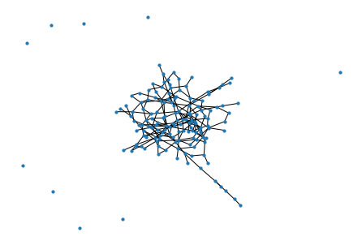

```python
import matplotlib.pyplot as plt

networkx.draw(graph, with_labels=False, node_size=10)
plt.show()
```

```python
print("Number of nodes: ", len(graph))
print("Number of edges: ", graph.number_of_edges())
```

```
Number of nodes:  150
Number of edges:  203
```

```python
import collections

def average_degree(graph):
    """
    Calculate the average degree of the network
    :param graph: the networkx Graph() object
    :return: the average degree of the network
    """
    k = map(lambda d: d[1], graph.degree())
    return sum(list(k)) / graph.number_of_nodes()

print("Avarage degree: ", average_degree(graph))
```

```
Avarage degree:  2.7066666666666666
```

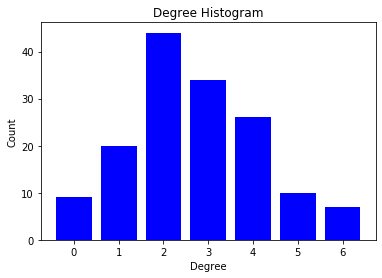

```python
# Plot istrogramma degree

degree_sequence = sorted([d for n, d in graph.degree()], reverse=True)  # degree sequence
# print "Degree sequence", degree_sequence
degreeCount = collections.Counter(degree_sequence)
deg, cnt = zip(*degreeCount.items())


plt.bar(deg, cnt, width=0.80, color='b')
plt.title("Degree Histogram")
plt.ylabel("Count")
plt.xlabel("Degree")
```

```python
print("Density: ", networkx.density(graph))
```

```
Density:  0.018165548098434004
```

```python
def connected_component_subgraphs(G):
    for c in networkx.connected_components(G):
        yield G.subgraph(c)

components = sorted(connected_component_subgraphs(graph), key=len, reverse=True)
print("There are ", len(components), " connected components")
print("Giant component size: ", len(components[0]))
```

```
There are  10  connected components
Giant component size:  141
```

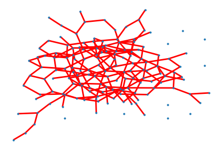

```python
# Plot del grafo con le varie componenti connesse colorate con diversi colori
# identify largest connected component
import pydot
from networkx.drawing.nx_pydot import graphviz_layout



pos = graphviz_layout(graph)

networkx.draw(graph, pos, with_labels=False, node_size=10)
# Getting largest connected component
graphcc = sorted(networkx.connected_components(graph), key=len, reverse=True)
graph0 = graph.subgraph(graphcc[0])
networkx.draw_networkx_edges(graph0, pos,
                        with_labels=False,
                        edge_color='r',
                        width=3.0
                        )
# show other connected components
for Gi in graphcc[1:]:
    if len(Gi) > 1:
        networkx.draw_networkx_edges(graph.subgraph(Gi), pos,
                                with_labels=False,
                                edge_color='r',
                                alpha=0.3,
                                width=2.0
                                )
```

Nelle celle seguenti andiamo quindi a misurare la distanza massima (diametro), minima (raggio) e media tra due punti qualsiasi del grafo.  
In realtà non è possibile trovare queste misure per tutto il grafo se non è completamente connesso perché il diametro e la media sarebbero uguali ad infinito. Ci riferiamo quindi solo alla giant component.

```python
print("Maximum eccentricity of giant component: ", networkx.diameter(components[0]))
```

```
Maximum eccentricity of giant component:  14
```

```python
print("Minimun eccentricity of giant component: ", networkx.radius(components[0]))
```

```
Minimun eccentricity of giant component:  7
```

```python
print("Average shortes path: ", networkx.average_shortest_path_length(components[0]))
```

```
Average shortes path:  5.208915906788247
```

Adesso andiamo ad analizzare il clustering coefficient e la transitivity che ci da un'idea di quanto i nodi siano connessi tra di loro e la percentuale di cliques all'interno del grafo.

```python
print("Average clustering coefficient: ", networkx.average_clustering(graph))
```

```
Average clustering coefficient:  0.015555555555555557
```

```python
print("Transitivity: ", networkx.transitivity(graph))
```

```
Transitivity:  0.01775147928994083
```

### Considerazioni

Come visto durante le lezioni il random graph ha una distanza tra i nodi dipende dal log(N), nel nostro caso abbiamo notato come con un p pari a 0.02 la distanza media (shortest path) è bassa perché il numero di nodi è basso.

Inoltre come ci si poteva aspettare i valori di clustering coefficient e di transitivity sono molto bassi, non rispecchiando la natura vera delle reti reali

#### Nodi importanti

In questa sezione si andrà ad analizzare quale nodi sono più importanti di altri, in base a metriche descritte in precedenza.

Questi nodi saranno poi target di attacchi per il 2nd assignment.

```python
print("10 nodi con degree maggiore")
dict(sorted(graph.degree, key=lambda x: x[1], reverse=True)[:10])
```

```
10 nodi con degree maggiore
```

```
{60: 6, 70: 6, 93: 6, 107: 6, 116: 6, 142: 6, 148: 6, 13: 5, 14: 5, 18: 5}
```

```python
import operator

print("10 nodi con maggiore closeness")
dict(sorted(networkx.closeness_centrality(graph).items(), key=operator.itemgetter(1),reverse=True)[:10])
```

```
10 nodi con maggiore closeness
```

```
{70: 0.23917022574740693,
 29: 0.23701553902896183,
 148: 0.23658925208826226,
 13: 0.2340633881869641,
 60: 0.2336476450463123,
 14: 0.22679935200185142,
 143: 0.22679935200185142,
 116: 0.2248608960018356,
 106: 0.2229552951882607,
 30: 0.22145391272908052}
```

```python
print("10 nodi con maggiore betweenness")
dict(sorted(networkx.betweenness_centrality(graph).items(), key=operator.itemgetter(1),reverse=True)[:10])
```

```
10 nodi con maggiore betweenness
```

```
{13: 0.14128553717479886,
 60: 0.11539737571616764,
 29: 0.10051825630684687,
 70: 0.0970219727770063,
 116: 0.09121653031049001,
 148: 0.085830470897585,
 4: 0.08498095410847088,
 107: 0.08392061336692207,
 97: 0.07835164437513428,
 81: 0.07633052297481831}
```

```python
print("10 nodi con maggiore clustering coefficient")
dict(sorted(networkx.clustering(graph).items(), key=operator.itemgetter(1),reverse=True)[:10])
```

```
10 nodi con maggiore clustering coefficient
```

```
{111: 1.0,
 124: 0.3333333333333333,
 32: 0.16666666666666666,
 55: 0.16666666666666666,
 74: 0.16666666666666666,
 100: 0.16666666666666666,
 120: 0.16666666666666666,
 98: 0.1,
 148: 0.06666666666666667,
 0: 0}
```

## Parte 2: Small world graph

In questa sezione andiamo ad analizzare un Watts-Strogatz small-world graph generato tramite networkx.

Il numero di nodi è uguale al grafo precedente, la sua p è uguale a 0.07, un valore che permette di dare risalto ai cossiddetti cluster di nodi.

```python
import networkx
graph = networkx.watts_strogatz_graph(150,4,0.07, seed=42)
```

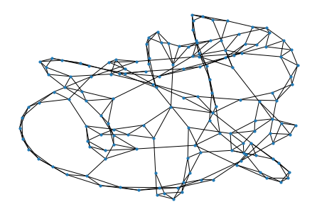

```python
import matplotlib.pyplot as plt

networkx.draw(graph, with_labels=False, node_size=10)
plt.show()
```

```python
print("Number of nodes: ", len(graph))
print("Number of edges: ", graph.number_of_edges())
```

```
Number of nodes:  150
Number of edges:  300
```

```python
import collections

def average_degree(graph):
    """
    Calculate the average degree of the network
    :param graph: the networkx Graph() object
    :return: the average degree of the network
    """
    k = map(lambda d: d[1], graph.degree())
    return sum(list(k)) / graph.number_of_nodes()

print("Avarage degree: ", average_degree(graph))
```

```
Avarage degree:  4.0
```

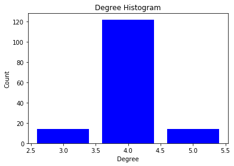

```python
# Plot istrogramma degree

degree_sequence = sorted([d for n, d in graph.degree()], reverse=True)  # degree sequence
# print "Degree sequence", degree_sequence
degreeCount = collections.Counter(degree_sequence)
deg, cnt = zip(*degreeCount.items())


plt.bar(deg, cnt, width=0.80, color='b')
plt.title("Degree Histogram")
plt.ylabel("Count")
plt.xlabel("Degree")
```

```python
print("Density: ", networkx.density(graph))
```

```
Density:  0.026845637583892617
```

```python
def connected_component_subgraphs(G):
    for c in networkx.connected_components(G):
        yield G.subgraph(c)

components = sorted(connected_component_subgraphs(graph), key=len, reverse=True)
print("There are ", len(components), " connected components")
print("Giant component size: ", len(components[0]))
```

```
There are  1  connected components
Giant component size:  150
```

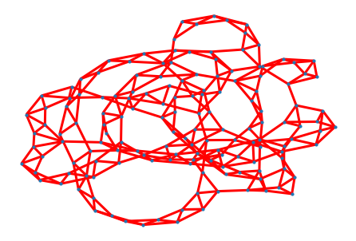

```python
# Plot del grafo con le varie componenti connesse colorate con diversi colori
# identify largest connected component
import pydot
from networkx.drawing.nx_pydot import graphviz_layout



pos = graphviz_layout(graph)

networkx.draw(graph, pos, with_labels=False, node_size=10)
# Getting largest connected component
graphcc = sorted(networkx.connected_components(graph), key=len, reverse=True)
graph0 = graph.subgraph(graphcc[0])
networkx.draw_networkx_edges(graph0, pos,
                        with_labels=False,
                        edge_color='r',
                        width=3.0
                        )
# show other connected components
for Gi in graphcc[1:]:
    if len(Gi) > 1:
        networkx.draw_networkx_edges(graph.subgraph(Gi), pos,
                                with_labels=False,
                                edge_color='r',
                                alpha=0.3,
                                width=2.0
                                )
```

Nelle celle seguenti andiamo quindi a misurare la distanza massima (diametro), minima (raggio) e media tra due punti qualsiasi del grafo.  
In realtà non è possibile trovare queste misure per tutto il grafo se non è completamente connesso perché la il diametro e la media sarebbero uguali ad infinito.

```python
print("Maximum eccentricity of giant component: ", networkx.diameter(components[0]))
```

```
Maximum eccentricity of giant component:  13
```

```python
print("Minimun eccentricity of giant component: ", networkx.radius(components[0]))
```

```
Minimun eccentricity of giant component:  9
```

```python
print("Average shortes path: ", networkx.average_shortest_path_length(components[0]))
```

```
Average shortes path:  6.403758389261745
```

Adesso andiamo ad analizzare il clustering coefficient e la transitivity che ci da un'idea di quanto i nodi siano connessi tra di loro e la percentuale di cliques all'interno del grafo.

```python
print("Average clustering coefficient: ", networkx.average_clustering(graph))
```

```
Average clustering coefficient:  0.40866666666666673
```

```python
print("Transitivity: ", networkx.transitivity(graph))
```

```
Transitivity:  0.40043763676148797
```

### Considerazioni

Quelli che sono interessanti da notare sono i valori di clustering e transitivity, notevolmente aumentati, proprio come analizzato in teoria.

Tuttavia nelle slide il coefficiente di clustering per p=0.07 era all'incirca 0.6; in questo caso invece è ancora un po' basso: 0.41

#### Nodi importanti

In questa sezione si andrà ad analizzare quale nodi sono più importanti di altri, in base a metriche descritte in precedenza.

Questi nodi saranno poi target di attacchi per il 2nd assignment.

```python
print("10 nodi con degree maggiore")
dict(sorted(graph.degree, key=lambda x: x[1], reverse=True)[:10])
```

```
10 nodi con degree maggiore
```

```
{5: 5, 8: 5, 19: 5, 23: 5, 28: 5, 33: 5, 58: 5, 94: 5, 97: 5, 99: 5}
```

```python
import operator

print("10 nodi con maggiore closeness")
dict(sorted(networkx.closeness_centrality(graph).items(), key=operator.itemgetter(1),reverse=True)[:10])
```

```
10 nodi con maggiore closeness
```

```
{67: 0.19225806451612903,
 8: 0.19176319176319176,
 63: 0.19127086007702182,
 65: 0.18932655654383734,
 138: 0.1871859296482412,
 23: 0.18671679197994986,
 68: 0.18671679197994986,
 39: 0.18601747815230962,
 103: 0.18259803921568626,
 130: 0.18126520681265207}
```

```python
print("10 nodi con maggiore betweenness")
dict(sorted(networkx.betweenness_centrality(graph).items(), key=operator.itemgetter(1),reverse=True)[:10])
```

```
10 nodi con maggiore betweenness
```

```
{8: 0.14364251848674506,
 138: 0.13338223911147962,
 39: 0.12408088052445593,
 23: 0.12107743748100876,
 28: 0.11049205384523476,
 67: 0.10991547068488763,
 29: 0.10739037407874734,
 103: 0.10297474610611422,
 84: 0.10127154398796283,
 68: 0.0958417558079358}
```

```python
print("10 nodi con maggiore clustering coefficient")
dict(sorted(networkx.clustering(graph).items(), key=operator.itemgetter(1),reverse=True)[:10])
```

```
10 nodi con maggiore clustering coefficient
```

```
{41: 0.6666666666666666,
 51: 0.6666666666666666,
 110: 0.6666666666666666,
 136: 0.6666666666666666,
 140: 0.6666666666666666,
 4: 0.5,
 6: 0.5,
 14: 0.5,
 15: 0.5,
 16: 0.5}
```

## Parte 3: Scale free graph

In questa sezione andiamo ad analizzare una scale free network generato tramite networkx, in particolare attraverso il modello Barabasi-Albert. Per cui il nostro esponente γ sarà uguale a 3.

Come prima il numero di nodi rimane inviariato, e ciascuno di esso è collegato rispettivamente con due nodi, preferibilmente con alta degree.

```python
import networkx
graph = networkx.barabasi_albert_graph(150,2, seed=42)
```

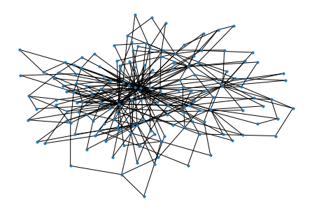

```python
import matplotlib.pyplot as plt

networkx.draw(graph, with_labels=False, node_size=10)
plt.show()
```

```python
print("Number of nodes: ", len(graph))
print("Number of edges: ", graph.number_of_edges())
```

```
Number of nodes:  150
Number of edges:  296
```

```python
import collections

def average_degree(graph):
    """
    Calculate the average degree of the network
    :param graph: the networkx Graph() object
    :return: the average degree of the network
    """
    k = map(lambda d: d[1], graph.degree())
    return sum(list(k)) / graph.number_of_nodes()

print("Avarage degree: ", average_degree(graph))
```

```
Avarage degree:  3.9466666666666668
```

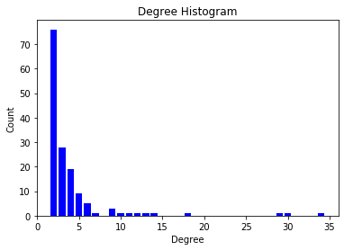

```python
# Plot istrogramma degree

degree_sequence = sorted([d for n, d in graph.degree()], reverse=True)  # degree sequence
# print "Degree sequence", degree_sequence
degreeCount = collections.Counter(degree_sequence)
deg, cnt = zip(*degreeCount.items())


plt.bar(deg, cnt, width=0.80, color='b')
plt.title("Degree Histogram")
plt.ylabel("Count")
plt.xlabel("Degree")
```

```python
print("Density: ", networkx.density(graph))
```

```
Density:  0.026487695749440716
```

```python
def connected_component_subgraphs(G):
    for c in networkx.connected_components(G):
        yield G.subgraph(c)

components = sorted(connected_component_subgraphs(graph), key=len, reverse=True)
print("There are ", len(components), " connected components")
print("Giant component size: ", len(components[0]))
```

```
There are  1  connected components
Giant component size:  150
```

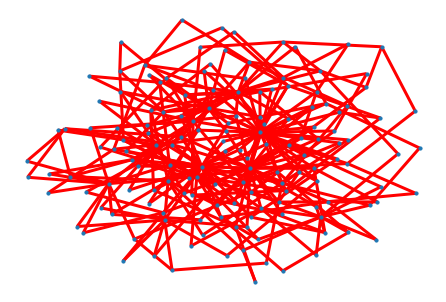

```python
# Plot del grafo con le varie componenti connesse colorate con diversi colori
# identify largest connected component
import pydot
from networkx.drawing.nx_pydot import graphviz_layout



pos = graphviz_layout(graph)

networkx.draw(graph, pos, with_labels=False, node_size=10)
# Getting largest connected component
graphcc = sorted(networkx.connected_components(graph), key=len, reverse=True)
graph0 = graph.subgraph(graphcc[0])
networkx.draw_networkx_edges(graph0, pos,
                        with_labels=False,
                        edge_color='r',
                        width=3.0
                        )
# show other connected components
for Gi in graphcc[1:]:
    if len(Gi) > 1:
        networkx.draw_networkx_edges(graph.subgraph(Gi), pos,
                                with_labels=False,
                                edge_color='r',
                                alpha=0.3,
                                width=2.0
                                )
```

Nelle celle seguenti andiamo quindi a misurare la distanza massima (diametro), minima (raggio) e media tra due punti qualsiasi del grafo.  
In realtà non è possibile trovare queste misure per tutto il grafo se non è completamente connesso perché la il diametro e la media sarebbero uguali ad infinito.

```python
print("Maximum eccentricity of giant component: ", networkx.diameter(components[0]))
```

```
Maximum eccentricity of giant component:  6
```

```python
print("Minimun eccentricity of giant component: ", networkx.radius(components[0]))
```

```
Minimun eccentricity of giant component:  3
```

```python
print("Average shortes path: ", networkx.average_shortest_path_length(components[0]))
```

```
Average shortes path:  3.1323489932885904
```

Adesso andiamo ad analizzare il clustering coefficient e la transitivity che ci da un'idea di quanto i nodi siano connessi tra di loro e la percentuale di cliques all'interno del grafo.

```python
print("Average clustering coefficient: ", networkx.average_clustering(graph))
```

```
Average clustering coefficient:  0.09180801769037063
```

```python
print("Transitivity: ", networkx.transitivity(graph))
```

```
Transitivity:  0.03905614320585842
```

### Considerazioni

Come si può vedere dall'istrogramma del grado dei vari nodi, abbiamo la media degree media pari a 3.9, ma sono presenti degli hub con degree maggiore a 30! Questi sono i nostri hubs, i nodi che andranno poi attaccati nel secondo assignment per far crollare la rete.

#### Nodi importanti

In questa sezione si andrà ad analizzare quale nodi sono più importanti di altri, in base a metriche descritte in precedenza.

Questi nodi saranno poi target di attacchi per il 2nd assignment.

```python
print("10 nodi con degree maggiore")
dict(sorted(graph.degree, key=lambda x: x[1], reverse=True)[:10])
```

```
10 nodi con degree maggiore
```

```
{2: 34, 4: 30, 1: 29, 0: 18, 5: 14, 3: 13, 24: 12, 8: 11, 49: 10, 17: 9}
```

```python
import operator

print("10 nodi con maggiore closeness")
dict(sorted(networkx.closeness_centrality(graph).items(), key=operator.itemgetter(1),reverse=True)[:10])
```

```
10 nodi con maggiore closeness
```

```
{2: 0.49337748344370863,
 1: 0.4837662337662338,
 4: 0.476038338658147,
 5: 0.415041782729805,
 0: 0.41046831955922863,
 3: 0.3962765957446808,
 8: 0.3850129198966408,
 16: 0.3850129198966408,
 17: 0.38303341902313626,
 19: 0.38107416879795397}
```

```python
print("10 nodi con maggiore betweenness")
dict(sorted(networkx.betweenness_centrality(graph).items(), key=operator.itemgetter(1),reverse=True)[:10])
```

```
10 nodi con maggiore betweenness
```

```
{2: 0.3205816343372213,
 4: 0.25595365666142317,
 1: 0.24614226092091887,
 0: 0.10213925428840956,
 5: 0.09695801611748044,
 3: 0.07769367754114362,
 24: 0.06594293637623737,
 8: 0.06008829850731735,
 17: 0.05014184224864904,
 27: 0.04842447606359394}
```

```python
print("10 nodi con maggiore clustering coefficient")
dict(sorted(networkx.clustering(graph).items(), key=operator.itemgetter(1),reverse=True)[:10])
```

```
10 nodi con maggiore clustering coefficient
```

```
{28: 1.0,
 46: 1.0,
 51: 1.0,
 63: 1.0,
 73: 1.0,
 103: 1.0,
 109: 1.0,
 122: 1.0,
 143: 1.0,
 64: 0.6666666666666666}
```

## Parte 4: dibris graph

In questa sezione andiamo ad analizzare il nostro grafo reale.

Di questo grafo è importante l'analisi per capire le connessioni tra i vari ricercatori del dibris. In particolare si può andare a verificare se è presente un rapporto di collaborazione tra tutti i componenti oppure si sono sviluppati sottogruppi di ricerca distinti tra loro.

Questo è profondamente diverso dal grafo delle pubblicazioni-citazioni visto in classe: i nodi sono persone e gli archi sono le collaborazioni, per cui all'interno non sono neanche rappresentate le pubblicazioni.  
Per questo motivo ci aspettiamo che sia molto simile ad un small world graph, rispetto che ad un grafo di tipo scale free come quello di pubblicazioni-citazioni, con diverse componenti connesse molto piccole.

```python
import networkx
graph = networkx.read_adjlist("../graphs/dibris_graph.txt")
```

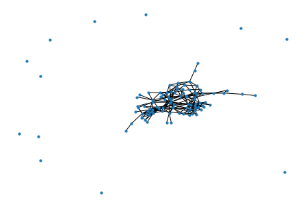

```python
import matplotlib.pyplot as plt

networkx.draw(graph, with_labels=False, node_size=10)
plt.show()
```

```python
print("Number of nodes: ", len(graph))
print("Number of edges: ", graph.number_of_edges())
```

```
Number of nodes:  103
Number of edges:  271
```

```python
import collections

def average_degree(graph):
    """
    Calculate the average degree of the network
    :param graph: the networkx Graph() object
    :return: the average degree of the network
    """
    k = map(lambda d: d[1], graph.degree())
    return sum(list(k)) / graph.number_of_nodes()

print("Avarage degree: ", average_degree(graph))
```

```
Avarage degree:  5.262135922330097
```

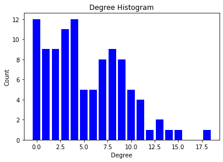

```python
# Plot istrogramma degree

degree_sequence = sorted([d for n, d in graph.degree()], reverse=True)  # degree sequence
# print "Degree sequence", degree_sequence
degreeCount = collections.Counter(degree_sequence)
deg, cnt = zip(*degreeCount.items())


plt.bar(deg, cnt, width=0.80, color='b')
plt.title("Degree Histogram")
plt.ylabel("Count")
plt.xlabel("Degree")
```

```python
print("Density: ", networkx.density(graph))
```

```
Density:  0.051589567865981345
```

```python
def connected_component_subgraphs(G):
    for c in networkx.connected_components(G):
        yield G.subgraph(c)

components = sorted(connected_component_subgraphs(graph), key=len, reverse=True)
print("There are ", len(components), " connected components")
print("Giant component size: ", len(components[0]))
```

```
There are  13  connected components
Giant component size:  91
```

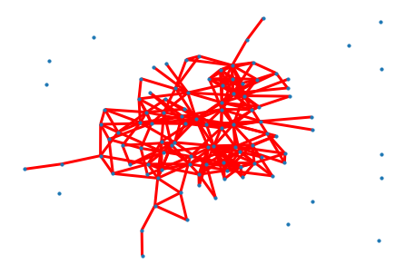

```python
# Plot del grafo con le varie componenti connesse colorate con diversi colori
# identify largest connected component
import pydot
from networkx.drawing.nx_pydot import graphviz_layout



pos = graphviz_layout(graph)

networkx.draw(graph, pos, with_labels=False, node_size=10)
# Getting largest connected component
graphcc = sorted(networkx.connected_components(graph), key=len, reverse=True)
graph0 = graph.subgraph(graphcc[0])
networkx.draw_networkx_edges(graph0, pos,
                        with_labels=False,
                        edge_color='r',
                        width=3.0
                        )
# show other connected components
for Gi in graphcc[1:]:
    if len(Gi) > 1:
        networkx.draw_networkx_edges(graph.subgraph(Gi), pos,
                                with_labels=False,
                                edge_color='r',
                                alpha=0.3,
                                width=2.0
                                )
```

Nelle celle seguenti andiamo quindi a misurare la distanza massima (diametro), minima (raggio) e media tra due punti qualsiasi del grafo.  
In realtà non è possibile trovare queste misure per tutto il grafo se non è completamente connesso perché la il diametro e la media sarebbero uguali ad infinito.

```python
print("Maximum eccentricity of giant component: ", networkx.diameter(components[0]))
```

```
Maximum eccentricity of giant component:  9
```

```python
print("Minimun eccentricity of giant component: ", networkx.radius(components[0]))
```

```
Minimun eccentricity of giant component:  5
```

```python
print("Average shortes path: ", networkx.average_shortest_path_length(components[0]))
```

```
Average shortes path:  3.3506715506715508
```

Adesso andiamo ad analizzare il clustering coefficient e la transitivity che ci da un'idea di quanto i nodi siano connessi tra di loro e la percentuale di cliques all'interno del grafo.

```python
print("Average clustering coefficient: ", networkx.average_clustering(graph))
```

```
Average clustering coefficient:  0.41761631667399807
```

```python
print("Transitivity: ", networkx.transitivity(graph))
```

```
Transitivity:  0.4007220216606498
```

### Considerazioni

Il grafo ci ha un po' sorpreso:

- Guardando solo la degree distribution non è così netta la tipologia di grafo (tra scale free e small world). Bisogna andare a vedere il coefficiente di clustering (0.40) per poter affermare che si avvicina di piu alle caratteristiche di un grafo small-world.
- Non ci aspettavamo una componente connessa così grande, comprendente il 90% dei nodi. Questo significa che c'é un buon livello di collaborazione, e conseguente scambio di conoscienze, all'interno del dipartimento.

Sono curiosi i dodici ricercatori con nessuna collaborazione interna al dibris, in parte dovuta al fatto che alcuni collaboratori non sono iscritti a Google Scholar, in parte a collaboratori stranieri entrati da poco a far parte del DIBRIS.

#### Nodi importanti

In questa sezione si andrà ad analizzare quale nodi sono più importanti di altri, in base a metriche descritte in precedenza.

Questi nodi saranno poi target di attacchi per il 2nd assignment.

```python
print("10 nodi con degree maggiore")
dict(sorted(graph.degree, key=lambda x: x[1], reverse=True)[:10])
```

```
10 nodi con degree maggiore
```

```
{'9dRRzV0AAAAJ': 18,
 'riK7DscAAAAJ': 15,
 'mX7J33sAAAAJ': 14,
 'fU0A1uIAAAAJ': 13,
 'wZtu8FYAAAAJ': 13,
 '42uk7BMAAAAJ': 12,
 'B19jA14AAAAJ': 11,
 'hVOrSewAAAAJ': 11,
 '7i3HX4wAAAAJ': 11,
 'sm7utHwAAAAJ': 11}
```

```python
import operator

print("10 nodi con maggiore closeness")
dict(sorted(networkx.closeness_centrality(graph).items(), key=operator.itemgetter(1),reverse=True)[:10])
```

```
10 nodi con maggiore closeness
```

```
{'9dRRzV0AAAAJ': 0.38549400342661333,
 'FmYjiNAAAAAJ': 0.37815126050420167,
 'riK7DscAAAAJ': 0.3659528327460016,
 'sm7utHwAAAAJ': 0.3577106518282989,
 'fU0A1uIAAAAJ': 0.3393665158371041,
 'Q5k0Nr0AAAAJ': 0.33226679793256214,
 '7i3HX4wAAAAJ': 0.326797385620915,
 'Rlc6k70AAAAJ': 0.32412965186074433,
 'tIongz8AAAAJ': 0.32412965186074433,
 'JRxJkaMAAAAJ': 0.32281205164992827}
```

```python
print("10 nodi con maggiore betweenness")
dict(sorted(networkx.betweenness_centrality(graph).items(), key=operator.itemgetter(1),reverse=True)[:10])
```

```
10 nodi con maggiore betweenness
```

```
{'9dRRzV0AAAAJ': 0.15676801136191093,
 'FmYjiNAAAAAJ': 0.14542792997009277,
 'riK7DscAAAAJ': 0.10629519956247249,
 'mX7J33sAAAAJ': 0.07815565321931853,
 'sm7utHwAAAAJ': 0.06851013366476093,
 'QEGbLC0AAAAJ': 0.06412712488107172,
 'tIongz8AAAAJ': 0.06255271134796711,
 'wZtu8FYAAAAJ': 0.060611592345311,
 '7nlRez0AAAAJ': 0.058327117187047285,
 'fU0A1uIAAAAJ': 0.05247444703187076}
```

```python
print("10 nodi con maggiore clustering coefficient")
dict(sorted(networkx.clustering(graph).items(), key=operator.itemgetter(1),reverse=True)[:10])
```

```
10 nodi con maggiore clustering coefficient
```

```
{'nMzsTbsAAAAJ': 1.0,
 'd69EGpEAAAAJ': 1.0,
 'ky3gHmYAAAAJ': 1.0,
 'aPSLBVUAAAAJ': 1.0,
 '9epB7x0AAAAJ': 1.0,
 'cFU6TRwAAAAJ': 1.0,
 'zMisBHkAAAAJ': 1.0,
 'dAZOMB8AAAAJ': 1.0,
 '9Nq_lpsAAAAJ': 1.0,
 'qVe_haIAAAAJ': 1.0}
```

### Considerazioni

Il nodo con maggiore degree è 9dRRzV0AAAAJ, che corrisponde a Mastrogiovanni Fulvio.